# Random forests for classification and regression. Practical examples in R

# Table of Contents

## Bagged random forests for classification

In this first part we get familiar with the `randomForest` package (Liaw and Wiener 2002) and the main components of a random forest object in R.

```r
if (!require("randomForest")) {
    install.packages("randomForest")
} else {
    library("randomForest")
}
```

### Example 1: classification with the iris dataset

```r
data(iris)
```

Dataset split for training and testing. The classical 70-30% partition is done:

```r
n <- nrow(iris)
set.seed(1)
indtrain <- sample(1:n, round(0.7*n))  # indices for train
indtest <- setdiff(1:n, indtrain)  # indices for test
```

```r
rf <- randomForest(Species ~., iris , subset = indtrain)
```

**Exploring the RF object structure. Questions:**

1. How many trees form the random forest?
2. How many predictors are sampled to grow each tree?
3. How many samples are drawn to grow each tree?
4. Can you provide an indication of the relative importance of each explanatory variable?
5. How is variable importance measured?

```r
## 1.How many trees form the random forest?
rf$ntree
```

500

```r
## 2. How many predictors are sampled to grow each tree?
rf$mtry
```

2

```r
## 3. How many samples are drawn to grow each tree?
## This can be seen looking at the default call to the function in the help menu <help("randomForest")> considering the default value of the 'sampsize' argument
# sampsize = if (replace) nrow(x) else ceiling(.632*nrow(x))
# Therefore, the number of samples taken in this case (replacement = TRUE), is
length(indtrain)
```

105

```r
## 4. Can you provide an indication of the relative importance of each explanatory variable?
rf$importance
```

A matrix: 4 × 1 of type dbl

|  | MeanDecreaseGini |
| --- | --- |
| Sepal.Length | 7.061638 |
| Sepal.Width | 1.896055 |
| Petal.Length | 31.783199 |
| Petal.Width | 28.418593 |

```r
## 5. How is variable importance measured?

# Variable importance is measured in this case (classification) using the mean decrease in Gini index (it measures group impurity).
# The greater the decrease, the more important is the variable for improving the classifier performance.
```

Next, the accuracy of the random forest classifier is calculated:

```r
pred <- predict(rf, iris[indtest, ])
(accuracy <- sum(diag(table(pred, iris$Species[indtest]))) / length(indtest))
```

0.955555555555556

### Comparison of the Random forest against a single tree

```r
library(tree)
myTree <- tree(Species ~., iris, subset = indtrain)
# prediction for test
pred.t <- predict(myTree, iris[indtest, ], type = "class")
accuracy.tree <- sum(diag(table(pred.t, iris$Species[indtest]))) / length(indtest)
accuracy.tree
```

0.911111111111111

Using exactly the same data, the Random Forest yields higher predictive accuracy

### Out-of-bag error

For each bootstrap sample taken from the training data, there will be samples left behind that were not included. These samples are called Out-Of-Bag samples (OOB). When averaged over all trees, the predictive performance on OOB samples provides a good estimate of the test error that may be expected.

The study of error estimates for bagged classifiers in [Breiman 1996](https://www.stat.berkeley.edu/~breiman/OOBestimation.pdf), gives empirical evidence to show that the out-of-bag estimate is as accurate as using a test set of the same size as the training set. Therefore, using the out-of-bag error estimate can be as useful as a sepparate test set for model assessment purposes.

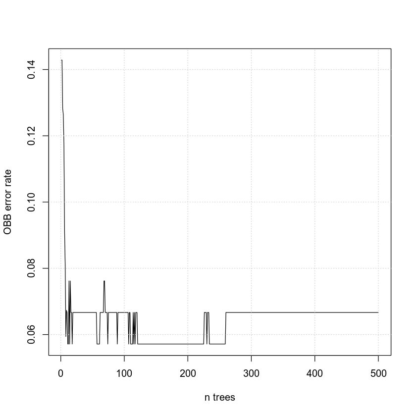

```r
plot(rf$err.rate[, 1], type = "l", xlab = "n trees", ylab = "OBB error rate")
grid()
```

Looking into the error rates more in detail, it is possible to ascertain its different components:

```r
str(rf$err.rate)
```

```
 num [1:500, 1:4] 0.143 0.143 0.128 0.126 0.117 ...
 - attr(*, "dimnames")=List of 2
  ..$ : NULL
  ..$ : chr [1:4] "OOB" "setosa" "versicolor" "virginica"
```

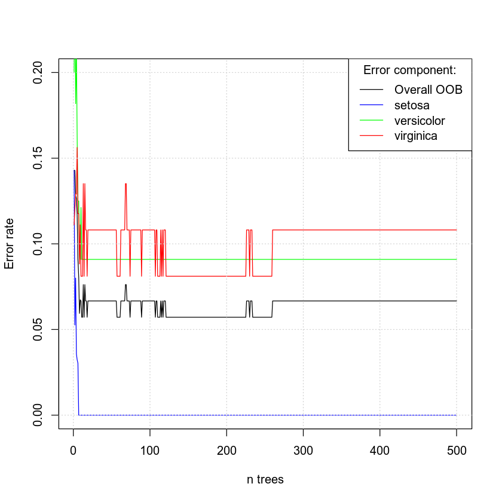

```r
plot(rf$err.rate[, 1], type = "l", xlab = "n trees", ylab = "Error rate",ylim=c(0,0.2))
lines(rf$err.rate[,2], col = "blue")
lines(rf$err.rate[,3], col = "green")
lines(rf$err.rate[,4], col = "red")
grid()
legend("topright", title="Error component:", c("Overall OOB", "setosa", "versicolor", "virginica"), lty = 1, col = c("black", "blue", "green", "red"))
```

**Questions**

1. What can you say after inspecting the above plot?
2. From the OOB error plot above, how many trees would you use for the random forest?

The minimum OOB error is attained approx around a 125-tree forest. This error then slightly increases and stabilizes, and therefore `ntree=125` seems here a sensible choice. Furthermore, In addition to the overall OOB error, the plot displays the individual classification error for each of the categories. In this example, the classification of setosa is perfect with a few trees. The classification of versicolor is not anymore improved after these few trees, so the OOB error variation for further trees is entirely due to the classification error of the virginica variety.

There are other parameters that have an important effect on the resulting predictive ability of the random forest. Three important ones are the number of trees forming the forest (argument `ntree`, as already seen), the number of samples taken in the bootstrapping procedure (`sampsize`) and the number of variables included as predictors in each bootstrap iteration (`mtree`). An example on how to decide suitable parameter values is shown in the next section.

### Example 2: Classification with the `meteo` dataset

Here, we will use the `meteo` dataset. The first column of the `meteo` dataset is the predictand (daily precipitation amount, in mm), and the rest of columns are the predictors, in blocks of 40 neighbouring locations corresponding to 8 different predictors. It contains a continuous record of 10958 days. For convenience, the data are next divided into predictand (first column) and predictors, and reduced to a subset of 1000 days to speed-up calculations. Furthermore, precipitation amount is converted to the binary variables rain/no rain for classification, considering a precipitation threshold of 1 mm. Afterwards, a new dataset is created:

```r
meteo <- read.table("~/DOCENCIA/2021_2022/M1966/datasets/meteo.csv", header = TRUE, sep = ",", row.names = 1)
```

```r
n <- 1000
y <- meteo[1:n, 1]  ## Predictando
x <- meteo[1:n, -1]  ## Predictores

# binary occurrence (1/0)
occ <- y
occ[which(y < 1)] <- 0
occ[which(y >= 1)] <- 1

# Occurrence dataset:
df.occ <- data.frame(y.bin = as.factor(occ), predictors = x)
```

The dataset is split into train and test subsets:

```r
set.seed(1)
indtrain <- sample(1:n, round(0.75*n))  # indices for train
indtest <- setdiff(1:n, indtrain)  # indices for test
```

The first model is constructed using all the default parameters. We set a seed for reproducibility (note that the boostrapping procedure entails a random sampling).

```r
set.seed(123)
rf <- randomForest(y.bin ~., df.occ, subset = indtrain)
```

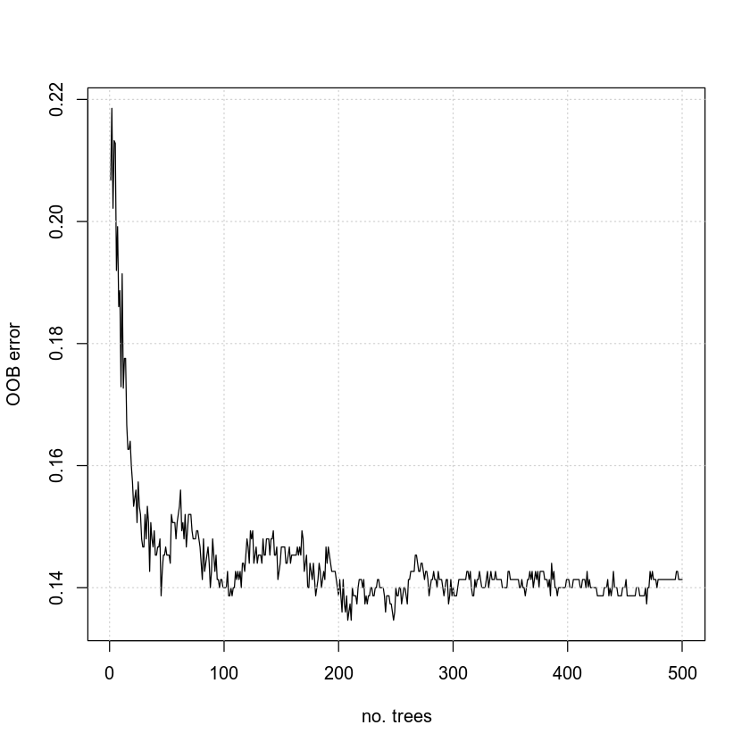

```r
plot(rf$err.rate[, 1], type = "l", xlab = "no. trees", ylab = "OOB error")
grid()
```

```r
pred <- predict(rf, df.occ[indtest, ])
(accuracy.rf <- sum(diag(table(pred, df.occ$y.bin[indtest]))) / length(indtest))  # error (1-accuracy)
```

0.916

It seems that with less trees a low error is attained:

```r
# Optimal number of trees is that minimizing the OOB error:
(ntree.optim <- which.min(rf$err.rate[, 1]))
```

208

### Fitting the optimum number of predictors (`mtry` parameter):

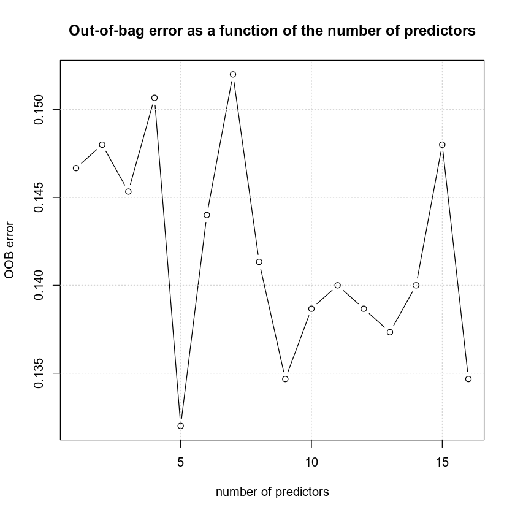

```r
# We search for the `mtry` value attaining minimum error:
mtry.choices <- 2:17 # From 2 to 17 predictors
err <- vector("numeric", length(mtry.choices))
for (i in 1:length(mtry.choices)) {
    set.seed(123)
    rf1 <- randomForest(y.bin ~., df.occ, subset = indtrain, ntree = ntree.optim, mtry = mtry.choices[i])
    pred1 <- predict(rf1, df.occ[indtest, ])
    err[i] <- rf1$err.rate[ntree.optim, 1]
}
plot(err, ty = "b", ylab = "OOB error", xlab = "number of predictors")
grid()
title(main = "Out-of-bag error as a function of the number of predictors")
```

```r
## results for optimum RF
mtry.best <- which.min(err)  # minimum OOB error
rf.best <- randomForest(y.bin ~., df.occ, subset = indtrain, ntree = ntree.optim, mtry = mtry.best)
```

The OOB error in this case:

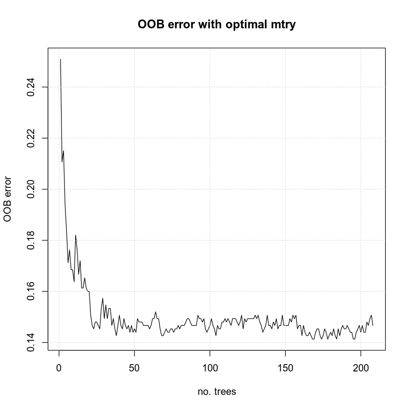

```r
plot(rf.best$err.rate[, 1], type = "l", xlab = "no. trees", ylab = "OOB error", main = "OOB error with optimal mtry")
grid()
```

```r
ntree.new <- which.min(rf.best$err.rate[, 1])
```

**Tuning the RF parameters. Questions:**

1. Following the example above, can you provide an optimal value for the bootstrapping sample size (`sampsize`) parameter?
2. Build a new random forest with all the estimated "optimal" parameters, providing a performance assessment (error rates and accuracy).
3. Compare the classification accuracy of this random forest with the random forest that uses default parameters, and alternative choices with differente parameter values. Is it possible to see a significant improvement after having determined the best parameter values?

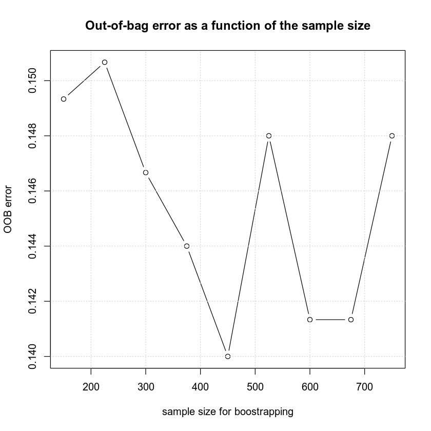

```r
# Next, we search for the `samplesize` value attaining minimum error:
# We consider the updated best number of trees (`ntree.new`)

sampsize.choices <- length(indtrain)*seq(0.2,1,0.1)
err <- vector("numeric", length(sampsize.choices))
for (i in 1:length(sampsize.choices)) {
    set.seed(1)
    rf1 <- randomForest(y.bin ~., df.occ, subset = indtrain,
                        sampsize = sampsize.choices[i],
                        ntree = ntree.new,
                        mtry = mtry.best)
    pred1 <- predict(rf1, df.occ[indtest, ])
    err[i] <- rf1$err.rate[ntree.new, 1]
}
plot(sampsize.choices, err, ty = "b", ylab = "OOB error", xlab = "sample size for boostrapping")
grid()
title(main = "Out-of-bag error as a function of the sample size")
```

```r
(best.sampsize <- sampsize.choices[which.min(err)])
```

450

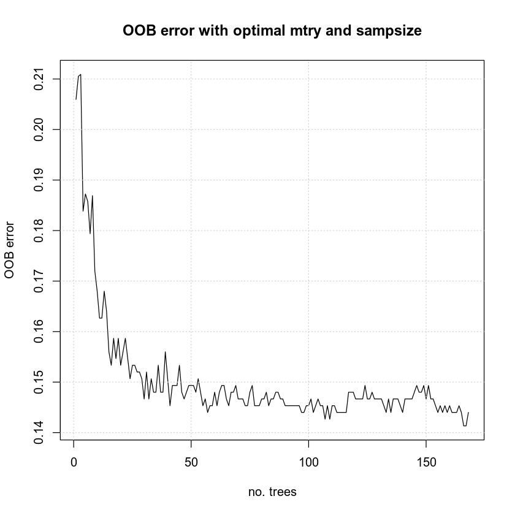

```r
rf.best.new <- randomForest(y.bin ~., df.occ, subset = indtrain, ntree = ntree.new,
                            mtry = mtry.best, sampsize = best.sampsize)
plot(rf.best.new$err.rate[, 1], type = "l",
     xlab = "no. trees",
     ylab = "OOB error",
     main = "OOB error with optimal mtry and sampsize")
grid()
```

In this case, we keep the current number of trees

```r
set.seed(123)
rf.optim <- randomForest(y.bin ~., df.occ, subset = indtrain,
                         sampsize = best.sampsize,
                         ntree = ntree.new, mtry = mtry.best)
```

```r
pred <- predict(rf.optim, df.occ[indtest, ])
(acc.best <- sum(diag(table(pred, df.occ$y.bin[indtest]))) / length(indtest))
```

0.9

## Bagged Random forests for regression

### Example 3: regression with the Boston dataset

```r
library(MASS)
n <- nrow(Boston) # train/test partition
indtrain <- sample(1:n, round(0.75*n))  # indices for train
indtest <- setdiff(1:n, indtrain) # indices for test
```

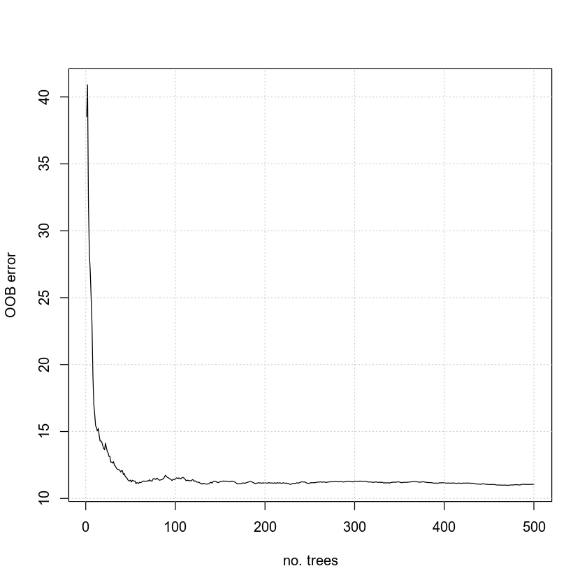

```r
set.seed(1)
rf <- randomForest(medv ~., Boston , subset = indtrain)
plot(rf$mse, type = "l", xlab = "no. trees", ylab = "OOB error")
grid()
```

**Questions**:

1. What is the measure of OOB error in the regression forest?
2. Build a random forest for regression optimizing the number of predictors for tree construction
3. Build a plot displaying the relative importance of each predictor
4. How is here variable importance measured?

In regression random forests, the error measure is based on the mean square errors. This is the sum of squared residuals divided by `n`.

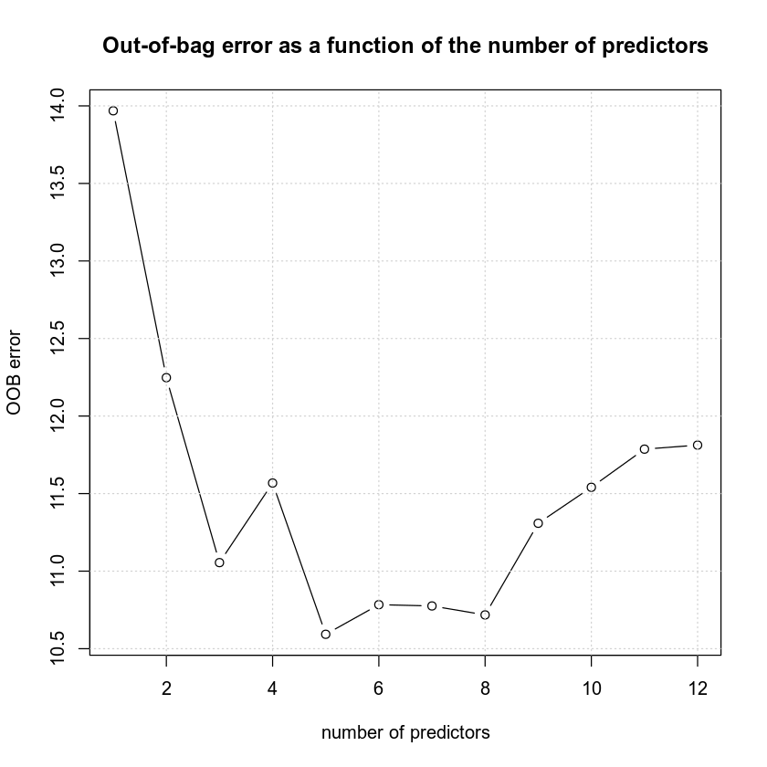

```r
# Optimization of predictor number
# Default ntree = 500 is maintained

mtry.vec <- 2:(ncol(Boston)-1)
err <- vector("numeric", length(mtry.vec))
for (i in 1:length(mtry.vec)) {
    set.seed(1)
    rf1 <- randomForest(medv ~., Boston, subset = indtrain, mtry = mtry.vec[i])
    # pred1 <- predict(rf1, Boston[indtest, ])
    err[i] <- tail(rf1$mse, 1)
}
plot(err, ty = "b", ylab = "OOB error", xlab = "number of predictors")
grid()
title(main = "Out-of-bag error as a function of the number of predictors")
```